# Predicting Income from Census Data

## Introduction

In this project, we employ several supervised learning algorithms to accurately model individuals' income using data collected from the 1994 U.S. Census. We choose the best candidate algorithm from preliminary results and further optimize this algorithm to best model the data. Our goal with this implementation is to construct a model that accurately predicts whether an individual makes more than \$50,000. This sort of task can arise in a non-profit setting, where organizations survive on donations. Understanding an individual's income can help a non-profit better understand how large donation to request, or whether or not they should reach out, to begin. While it can be difficult to determine an individual's general income bracket directly from public sources, we can infer this value from other publicly available features.

The dataset for this project originates from the [UCI Machine Learning Repository](https://archive.ics.uci.edu/ml/datasets/Census+Income). The dataset was donated by Ron Kohavi and Barry Becker, after being published in the article *"Scaling Up the Accuracy of Naive-Bayes Classifiers: A Decision-Tree Hybrid"*. The article by Ron Kohavi can be found [online](https://www.aaai.org/Papers/KDD/1996/KDD96-033.pdf). The data we investigate here consists of small changes to the original dataset, such as removing the `'fnlwgt'` feature and records with missing or ill-formatted entries.

## Exploring the Data

We need to load the necessary Python libraries and load the census data. Note that the last column from this dataset, `'income'`, will be our target label (whether an individual makes more than, or at most, \$50,000 annually). All other columns are features about each individual in the census database.

```python
# Import libraries necessary for this project
import numpy as np
import pandas as pd
from time import time
from sklearn.model_selection import train_test_split, GridSearchCV
from sklearn.metrics import fbeta_score, accuracy_score, make_scorer
from sklearn.preprocessing import MinMaxScaler
from sklearn.base import clone
from sklearn.linear_model import LogisticRegression
from sklearn.svm import LinearSVC
from sklearn.ensemble import GradientBoostingClassifier
from IPython.display import display  # Allows the use of display() for DataFrames

# Import supplementary visualization code visuals.py
import visuals as vs

# Load the Census dataset
data = pd.read_csv("census.csv")

# Success - Display the first record
display(data.head(1))
```

|  | age | workclass | education_level | education-num | marital-status | occupation | relationship | race | sex | capital-gain | capital-loss | hours-per-week | native-country | income |
| --- | --- | --- | --- | --- | --- | --- | --- | --- | --- | --- | --- | --- | --- | --- |
| 0 | 39 | State-gov | Bachelors | 13.0 | Never-married | Adm-clerical | Not-in-family | White | Male | 2174.0 | 0.0 | 40.0 | United-States | <=50K |

### Implementation: Data Exploration

A cursory investigation of the dataset can determine how many individuals fit into either group and tells us about the percentage of these individuals making more than \$50,000. In the code cell below, we compute the following:

- The total number of records, `'n_records'`
- The number of individuals making more than \$50,000 annually, `'n_greater_50k'`.
- The number of individuals making at most \$50,000 annually, `'n_at_most_50k'`.
- The percentage of individuals making more than \$50,000 annually, `'greater_percent'`.

```python
# Total number of records
n_records = data.shape[0]

# Number of records where individual's income is more than $50,000
n_greater_50k = data[data.income == '>50K'].shape[0]

# Number of records where individual's income is at most $50,000
n_at_most_50k = data[data.income == '<=50K'].shape[0]

# Percentage of individuals whose income is more than $50,000
greater_percent = n_greater_50k * 100.0 / n_records

# Print the results
print("Total number of records: {}".format(n_records))
print("Individuals making more than $50,000: {}".format(n_greater_50k))
print("Individuals making at most $50,000: {}".format(n_at_most_50k))
print("Percentage of individuals making more than $50,000: {:.2f}%".format(
    greater_percent))
```

```
Total number of records: 45222
Individuals making more than $50,000: 11208
Individuals making at most $50,000: 34014
Percentage of individuals making more than $50,000: 24.78%
```

**Featureset Exploration**

- **age**: continuous.
- **workclass**: Private, Self-emp-not-inc, Self-emp-inc, Federal-gov, Local-gov, State-gov, Without-pay, Never-worked.
- **education**: Bachelors, Some-college, 11th, HS-grad, Prof-school, Assoc-acdm, Assoc-voc, 9th, 7th-8th, 12th, Masters, 1st-4th, 10th, Doctorate, 5th-6th, Preschool.
- **education-num**: continuous.
- **marital-status**: Married-civ-spouse, Divorced, Never-married, Separated, Widowed, Married-spouse-absent, Married-AF-spouse.
- **occupation**: Tech-support, Craft-repair, Other-service, Sales, Exec-managerial, Prof-specialty, Handlers-cleaners, Machine-op-inspct, Adm-clerical, Farming-fishing, Transport-moving, Priv-house-serv, Protective-serv, Armed-Forces.
- **relationship**: Wife, Own-child, Husband, Not-in-family, Other-relative, Unmarried.
- **race**: Black, White, Asian-Pac-Islander, Amer-Indian-Eskimo, Other.
- **sex**: Female, Male.
- **capital-gain**: continuous.
- **capital-loss**: continuous.
- **hours-per-week**: continuous.
- **native-country**: United-States, Cambodia, England, Puerto-Rico, Canada, Germany, Outlying-US(Guam-USVI-etc), India, Japan, Greece, South, China, Cuba, Iran, Honduras, Philippines, Italy, Poland, Jamaica, Vietnam, Mexico, Portugal, Ireland, France, Dominican-Republic, Laos, Ecuador, Taiwan, Haiti, Columbia, Hungary, Guatemala, Nicaragua, Scotland, Thailand, Yugoslavia, El-Salvador, Trinadad&Tobago, Peru, Hong, Holand-Netherlands.

```python
data.dtypes
```

```
age                  int64
workclass           object
education_level     object
education-num      float64
marital-status      object
occupation          object
relationship        object
race                object
sex                 object
capital-gain       float64
capital-loss       float64
hours-per-week     float64
native-country      object
income              object
dtype: object
```

Data type of each column match with the intended type.

## Preparing the Data

Before data can be used as input for machine learning algorithms, it must be cleaned, formatted, and restructured — this is typically known as **preprocessing**. Fortunately, for this dataset, there are no invalid or missing entries we must deal with; however, there are some qualities about specific features that must be adjusted. This preprocessing can help tremendously with the outcome and predictive power of nearly all learning algorithms.

### Transforming Skewed Continuous Features

A dataset may sometimes contain at least one feature whose values tend to lie near a single number, but will also have a non-trivial number of vastly larger or smaller values than that single number. Algorithms can be sensitive to such distributions of values and can underperform if the range is not properly normalized. With the census dataset, two features fit this description: '`capital-gain'` and `'capital-loss'`.

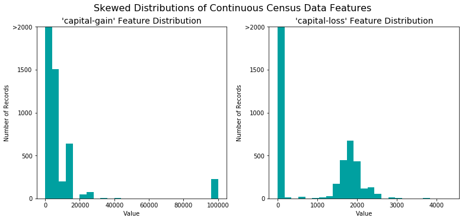

```python
# Split the data into features and target label
income_raw = data['income']
features_raw = data.drop('income', axis=1)

# Visualize skewed continuous features of original data
vs.distribution(features_raw)
```

For highly-skewed feature distributions such as `'capital-gain'` and `'capital-loss'`, it is common practice to apply a logarithmic transformation on the data so that the extreme values do not negatively affect the performance of a learning algorithm. Using a logarithmic transformation significantly reduces the range of values caused by outliers. Care must be taken when applying this transformation, however: The logarithm of `0` is undefined, so we must translate the values by a small amount above `0` to apply the logarithm successfully.

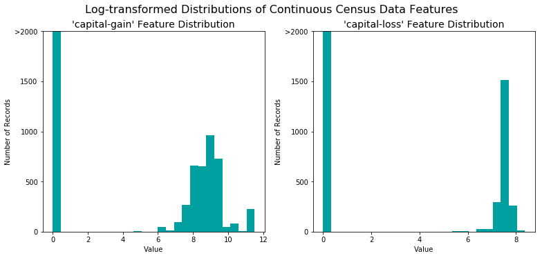

```python
# Log-transform the skewed features
skewed = ['capital-gain', 'capital-loss']
features_log_transformed = pd.DataFrame(data=features_raw)
features_log_transformed[skewed] = features_raw[skewed].apply(
    lambda x: np.log(x + 1))

# Visualize the new log distributions
vs.distribution(features_log_transformed, transformed=True)
```

### Normalizing Numerical Features

In addition to performing transformations on features that are highly skewed, it is often good practice to perform some scaling on numerical features. Applying a scaling to the data does not change the shape of each feature's distribution (such as `'capital-gain'` or `'capital-loss'` above); however, normalization ensures that each feature is treated equally when applying supervised learners. Note that once scaling is applied, observing the data in its raw form will no longer have the same original meaning, as exampled below.

```python
# Initialize a scaler, then apply it to the features
scaler = MinMaxScaler()  # default=(0, 1)
numerical = [
    'age', 'education-num', 'capital-gain', 'capital-loss', 'hours-per-week'
]

features_log_minmax_transform = pd.DataFrame(data=features_log_transformed)
features_log_minmax_transform[numerical] = scaler.fit_transform(
    features_log_transformed[numerical])

# Show an example of a record with scaling applied
display(features_log_minmax_transform.head())
```

|  | age | workclass | education_level | education-num | marital-status | occupation | relationship | race | sex | capital-gain | capital-loss | hours-per-week | native-country |
| --- | --- | --- | --- | --- | --- | --- | --- | --- | --- | --- | --- | --- | --- |
| 0 | 0.301370 | State-gov | Bachelors | 0.800000 | Never-married | Adm-clerical | Not-in-family | White | Male | 0.667492 | 0.0 | 0.397959 | United-States |
| 1 | 0.452055 | Self-emp-not-inc | Bachelors | 0.800000 | Married-civ-spouse | Exec-managerial | Husband | White | Male | 0.000000 | 0.0 | 0.122449 | United-States |
| 2 | 0.287671 | Private | HS-grad | 0.533333 | Divorced | Handlers-cleaners | Not-in-family | White | Male | 0.000000 | 0.0 | 0.397959 | United-States |
| 3 | 0.493151 | Private | 11th | 0.400000 | Married-civ-spouse | Handlers-cleaners | Husband | Black | Male | 0.000000 | 0.0 | 0.397959 | United-States |
| 4 | 0.150685 | Private | Bachelors | 0.800000 | Married-civ-spouse | Prof-specialty | Wife | Black | Female | 0.000000 | 0.0 | 0.397959 | Cuba |

### Implementation: Data Preprocessing

From the table in **Exploring the Data** above, we can see there are several features for each record that are non-numeric. Typically, learning algorithms expect input to be numeric, which requires that non-numeric features (called *categorical variables*) be converted. One popular way to convert categorical variables is by using the **one-hot encoding** scheme. One-hot encoding creates a *"dummy"* variable for each possible category of each non-numeric feature. For example, assume `someFeature` has three possible entries: `A`, `B`, or `C`. We then encode this feature into `someFeature_A`, `someFeature_B` and `someFeature_C`.

|  | someFeature |  | someFeature_A | someFeature_B | someFeature_C |
| --- | --- | --- | --- | --- | --- |
| 0 | B |  | 0 | 1 | 0 |
| 1 | C | ----> one-hot encode ----> | 0 | 0 | 1 |
| 2 | A |  | 1 | 0 | 0 |

Additionally, as with the non-numeric features, we need to convert the non-numeric target label, `'income'` to numerical values for the learning algorithm to work. Since there are only two possible categories for this label ("<=50K" and ">50K"), we can avoid using one-hot encoding and encode these two categories as `0` and `1`, respectively. In the code cell below, we implement the following:

- Use [`pandas.get_dummies()`](http://pandas.pydata.org/pandas-docs/stable/generated/pandas.get_dummies.html?highlight=get_dummies#pandas.get_dummies) to perform one-hot encoding on the `'features_raw'` data.
- Convert the target label `'income_raw'` to numerical entries.

```python
# TODO: One-hot encode the 'features_log_minmax_transform' data using pandas.get_dummies()
features_final = pd.get_dummies(features_raw)

# TODO: Encode the 'income_raw' data to numerical values
income = income_raw.apply(lambda x: int(x == '>50K'))

# Print the number of features after one-hot encoding
encoded = list(features_final.columns)
print("{} total features after one-hot encoding.".format(len(encoded)))

# Uncomment the following line to see the encoded feature names
#print(encoded)
```

```
103 total features after one-hot encoding.
```

### Shuffle and Split Data

Now all *categorical variables* have been converted into numerical features, and all numerical features have been normalized. As always, we will now split the data (both features and their labels) into training and test sets. 80% of the data will be used for training and 20% for testing.

```python
# Split the 'features' and 'income' data into training and testing sets
X_train, X_test, y_train, y_test = train_test_split(features_final,
                                                    income,
                                                    test_size = 0.2,
                                                    random_state = 0)

# Show the results of the split
print("Training set has {} samples.".format(X_train.shape[0]))
print("Testing set has {} samples.".format(X_test.shape[0]))
```

```
Training set has 36177 samples.
Testing set has 9045 samples.
```

## Evaluating Model Performance

In this section, we will investigate four different algorithms, and determine which is best at modeling the data. One of these is known as a *naive predictor*.

### Metrics and the Naive Predictor

In a scenario where we want to run a charity for a non-profit organization, we know that individuals who make more than \$50,000 are most likely to donate. Because of this, we are particularly interested in predicting who makes more than \$50,000 accurately. It would seem that using **accuracy** as a metric for evaluating a particular model's performance would be appropriate. Additionally, identifying someone that *does not* make more than \$50,000 as someone who does would be detrimental, since we are looking to find individuals willing to donate. Therefore, a model's ability to precisely predict those that make more than \$50,000 is *more important* than the model's ability to **recall** those individuals. We can use **F-beta score** as a metric that considers both precision and recall:

$$ F_{\beta} = (1 + \beta^2) \cdot \frac{precision \cdot recall}{\left( \beta^2 \cdot precision \right) + recall} $$

In particular, when $\beta = 0.5$, more emphasis is placed on precision. This is called the **F$_{0.5}$ score** (or F-score for simplicity).

Looking at the distribution of classes (those who make at most \$50,000, and those who make more), it is clear most individuals do not make more than \$50,000. This can significantly affect **accuracy**, since we could just say *"this person does not make more than \$50,000"* and generally be right, without ever looking at the data! Making such a statement would be called **naive** since we have not considered any information to substantiate the claim. It is always important to consider the *naive prediction* for our data, to help establish a benchmark for whether a model is performing well. That been said, using that prediction would be pointless: If we predicted all people made less than \$50,000, we would identify no one as donors.

#### Note: Recap of accuracy, precision, recall

**Accuracy** measures how often the classifier makes the correct prediction. It is the ratio of the number of correct predictions to the total number of predictions (the number of test data points).

**Precision** tells us what proportion of messages we classified as spam, actually were spam. It is a ratio of true positives (words classified as spam, and which are actually spam) to all positives (all words classified as spam, irrespective of whether that was the correct classification), in other words, it is the ratio of

$$\frac{True Positives}{True Positives + False Positives}$$

**Recall(sensitivity)** tells us what proportion of messages that actually were spam were classified by us as spam. It is a ratio of true positives(words classified as spam, and which are actually spam) to all the words that were actually spam, in other words, it is the ratio of

$$\frac{True Positives}{True Positives + False Negatives}$$

For classification problems that are skewed in their classification distributions like in our case, accuracy by itself is not a very good metric. For such cases, precision and recall come in very handy. These two metrics can be combined to get the F1 score, which is the weighted average (harmonic mean) of the precision and recall scores. This score can range from 0 to 1, with 1 being the best possible F1 score(we take the harmonic mean as we are dealing with ratios).

### Calculating **Accuracy** and **F-score** for the Naive Predictor

```python
# Calculate accuracy, precision and recall
true_positives = sum(y_train.append(y_test))
true_negatives = 0
false_positives = y_train.append(y_test).value_counts()[0]
false_negatives = 0

accuracy = true_positives / (true_positives + false_positives)
precision = true_positives / (true_positives + false_positives)
recall = true_positives / (true_positives + false_negatives)

# Calculate F-score using the formula above for beta = 0.5 and correct values
#for precision and recall.
beta = 0.5
fscore = (1 + beta**2) * (precision * recall) / (
    (beta**2 * precision) + recall)

# Print the results
print("Naive Predictor: [Accuracy score: {:.4f}, F-score: {:.4f}]".format(
    accuracy, fscore))
```

```
Naive Predictor: [Accuracy score: 0.2478, F-score: 0.2917]
```

### Supervised Learning Models

The three models that seem appropriate for the specific problem and will be evaluated are:

- Logistic Regression
- Support Vector Machines (SVM)
- Gradient Boosting

For each one of them, we describe one real-world application in industry, the strengths, and weaknesses and explain why this model a good candidate for the problem.

#### Logistic Regression

Logistic regression can be used in situations where we want to predict in which of two categories someone is most probable to belong. As an example, we can use it to classify voters in two parties and predict the result of the vote.

Strengths:

- Dependent variables do not have to be normally distributed,
- Independent variables can be categorical variable and bounded
- Can work on both linear and non-linear relationship between the input and output variables,
- Can be updated easily with new data using stochastic gradient descent.

Weaknesses:

- Requires large sample size to achieve stable results,
- Performance decreases if the function has too many non-linear relationships,
- Not adaptable to more complex situations,
- Not flexible enough to naturally capture more complex relationships.

The dataset has a lot of categorical variables which Logistic regression handles easily. Additionally, it is fast and straightforward algorithm, so most of the time worth give it a try.

#### Support Vector Machines

SVMs are helpful in text and hypertext categorization as their application can significantly reduce the need for labeled training instances in both the standard inductive and transductive settings.

Strengths:

- Effective in high dimensional spaces.
- Still effective in cases where the number of dimensions is greater than the number of samples.
- Uses a subset of training points in the decision function (called support vectors), so it is also memory efficient.
- Versatile: different [Kernel functions](http://scikit-learn.org/stable/modules/svm.html#svm-kernels) can be specified for the decision function. Common kernels are provided, but it is also possible to specify custom kernels.

Weaknesses:

- If the number of features is much greater than the number of samples, avoid over-fitting in choosing [Kernel functions](http://scikit-learn.org/stable/modules/svm.html#svm-kernels), and regularization term is crucial.
- SVMs do not directly provide probability estimates, these are calculated using an expensive five-fold cross-validation.  
  (Source: [Scikit Learn](http://scikit-learn.org/stable/modules/svm.html#classification))

After the pre-processing of the dataset we ended up with 103 features. The effectiveness of SVMs in high dimensional spaces seems appropriate for the problem.

#### Gradient Boosting

Gradient boosting can be used in the field of learning to rank. The commercial web search engines Yahoo and Yandex use variants of gradient boosting in their machine-learned ranking engines. (source: [Wikipedia](https://en.wikipedia.org/wiki/Gradient_boosting#Usage)).

Strengths:

- Natural handling of data of mixed type (= heterogeneous features)
- Predictive power
- Robustness to outliers in output space (via robust loss functions)

Weaknesses:

- Scalability, due to the sequential nature of boosting it can hardly be parallelized.  
  (Source: [Scikit Learn](http://scikit-learn.org/stable/modules/ensemble.html#gradient-tree-boosting))

Gradient Boosting is one of the most robust algorithms, and our dataset's size allows us to use it in a reasonable time.

### Implementation: Creating a Training and Predicting Pipeline

To properly evaluate the performance of each model we have chosen, it is important to create a training and predicting pipeline that allows us to quickly and effectively train models using various sizes of training data and perform predictions on the testing data. Our implementation here will follow the following steps:

- Import `fbeta_score` and `accuracy_score` from [`sklearn.metrics`](http://scikit-learn.org/stable/modules/classes.html#sklearn-metrics-metrics).
- Fit the learner to the sampled training data and record the training time.
- Perform predictions on the test data `X_test`, and also on the first 300 training points `X_train[:300]`.
  - Record the total prediction time.
- Calculate the accuracy score for both the training subset and testing set.
- Calculate the F-score for both the training subset and testing set.

```python
def train_predict(learner, sample_size, X_train, y_train, X_test, y_test):
    '''
    inputs:
       - learner: the learning algorithm to be trained and predicted on
       - sample_size: the size of samples (number) to be drawn from training set
       - X_train: features training set
       - y_train: income training set
       - X_test: features testing set
       - y_test: income testing set
    '''

    results = {}

    # Fit the learner to the training data using slicing with
    #'sample_size' using .fit(training_features[:], training_labels[:])
    start = time()  # Get start time
    learner = learner.fit(X_train[:sample_size], y_train[:sample_size])
    end = time()  # Get end time

    # Calculate the training time
    results['train_time'] = end - start

    # TODO: Get the predictions on the test set(X_test),
    #       then get predictions on the first 300 training samples(X_train)
    #       using .predict()
    start = time()  # Get start time
    predictions_test = learner.predict(X_test)
    predictions_train = learner.predict(X_train[:300])
    end = time()  # Get end time

    # Calculate the total prediction time
    results['pred_time'] = end - start

    # Compute accuracy on the first 300 training samples which is y_train[:300]
    results['acc_train'] = accuracy_score(y_train[:300],
                                          predictions_train[:300])

    # Compute accuracy on test set using accuracy_score()
    results['acc_test'] = accuracy_score(y_test, predictions_test)

    # Compute F-score on the the first 300 training samples using fbeta_score()
    results['f_train'] = fbeta_score(
        y_train[:300], predictions_train[:300], beta=0.5)

    # Compute F-score on the test set which is y_test
    results['f_test'] = fbeta_score(y_test, predictions_test, beta=0.5)

    # Success
    print("{} trained on {} samples.".format(learner.__class__.__name__,
                                             sample_size))

    # Return the results
    return results
```

### Implementation: Initial Model Evaluation

To evaluate the initial performance of the models, we need to perform the following tasks:

- Import the three supervised learning models we have discussed in the previous section.
- Initialize the three models and store them in `'clf_A'`, `'clf_B'`, and `'clf_C'`.
- Calculate the number of records equal to 1%, 10%, and 100% of the training data.

```
LogisticRegression trained on 361 samples.
LogisticRegression trained on 3617 samples.
LogisticRegression trained on 36177 samples.
LinearSVC trained on 361 samples.
LinearSVC trained on 3617 samples.
LinearSVC trained on 36177 samples.
GradientBoostingClassifier trained on 361 samples.
GradientBoostingClassifier trained on 3617 samples.
GradientBoostingClassifier trained on 36177 samples.
```

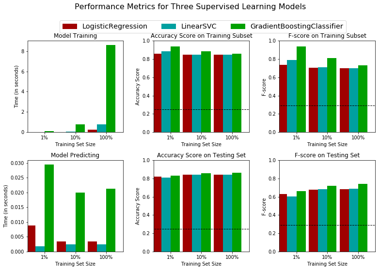

```python
# Initialize the three models

clf_A = LogisticRegression(random_state=42)
clf_B = LinearSVC(random_state=42)
clf_C = GradientBoostingClassifier(random_state=42)

# Calculate the number of samples for 1%, 10%, and 100% of the training data
# HINT: samples_100 is the entire training set i.e. len(y_train)
# HINT: samples_10 is 10% of samples_100
# HINT: samples_1 is 1% of samples_100
samples_100 = len(y_train)
samples_10 = int(samples_100/10)
samples_1 = int(samples_100/100)

# Collect results on the learners
results = {}
for clf in [clf_A, clf_B, clf_C]:
    clf_name = clf.__class__.__name__
    results[clf_name] = {}
    for i, samples in enumerate([samples_1, samples_10, samples_100]):
        results[clf_name][i] = \
        train_predict(clf, samples, X_train, y_train, X_test, y_test)

# Run metrics visualization for the three supervised learning models chosen

vs.evaluate(results, accuracy, fscore)
```

## Improving Results

In this final section, we will choose from the three supervised learning models the *best* model to use on the student data. We will then perform a grid search optimization for the model over the entire training set (`X_train` and `y_train`) by tuning the parameters to improve upon the untuned model's F-score.

Trying to explain in layman's terms, how the final model is supposed to work we can use the following example:

Imagine 20 teams (trees) of 5 members each (explanatory variables). A boss at the top, then subordinates, then more subordinates, and so on. We give them a book to read, and they have to answer 20 questions (Number of observations in our data). Assume they have binary answers: Yes or No. Now, we start the process. The process aims to maximize the correct answers by building 20 teams of 5 members each. Any member can be a part of more than one team, and any member can have more than one role on the same team. The member who has the maximum number of roles is the most critical variable of our model.

The process starts with a random guess of answers. These answers will create an error ( = Actual - Predicted Answer). Next step, we build a team of 5 members, which reduces the error by the most it can. Again, we calculate the error. The second team (tree) has to reduce it further, but it does not trust its previous partner entirely, so it assumes that the answers are correct with x probability (learning rate). This process goes on until 20 teams are built. So in the process, we have to decide, how many teams to build (trees), the members of each team(depth) and learning team, so that the error, in the end, is minimum. Trial and error method can only do this.

(Adapted by the original post of [Vinod Gattani in Quora](https://www.quora.com/What-is-Gradient-Boosting-Models-and-Random-Forests-using-layman-terms))

### Implementation: Model Tuning

To fine tune the chosen model, we will use grid search (`GridSearchCV`) with the following important parameter tuned:

- Learning Rate
- Number of Estimators

```python
# Initialize the classifier
clf = GradientBoostingClassifier(random_state=42)

# Create the parameters list.
parameters = [{'learning_rate': [0.05, 0.1, 0.15]},
              {'n_estimators' : [250, 500, 750]}
              ]

# Make an fbeta_score scoring object using make_scorer()
scorer = make_scorer(fbeta_score, beta=0.5)

# Perform grid search on the classifier using 'scorer' as the scoring method using GridSearchCV()
grid_obj = GridSearchCV(clf, parameters, scoring=scorer , n_jobs=-1)

# Fit the grid search object to the training data and find the optimal parameters using fit()
grid_fit = grid_obj.fit(X_train, y_train)

# Get the estimator
best_clf = grid_fit.best_estimator_

# Make predictions using the unoptimized and model
predictions = (clf.fit(X_train, y_train)).predict(X_test)
best_predictions = best_clf.predict(X_test)

# Report the before-and-afterscores
print("Unoptimized model\n------")
print("Accuracy score on testing data: {:.4f}".format(accuracy_score(y_test, predictions)))
print("F-score on testing data: {:.4f}".format(fbeta_score(y_test, predictions, beta = 0.5)))
print("\nOptimized Model\n------")
print("Final accuracy score on the testing data: {:.4f}".format(accuracy_score(y_test, best_predictions)))
print("Final F-score on the testing data: {:.4f}".format(fbeta_score(y_test, best_predictions, beta = 0.5)))
```

```
Unoptimized model
------
Accuracy score on testing data: 0.8630
F-score on testing data: 0.7395

Optimized Model
------
Final accuracy score on the testing data: 0.8719
Final F-score on the testing data: 0.7547
```

```python
best_clf
```

```
GradientBoostingClassifier(criterion='friedman_mse', init=None,
              learning_rate=0.1, loss='deviance', max_depth=3,
              max_features=None, max_leaf_nodes=None,
              min_impurity_decrease=0.0, min_impurity_split=None,
              min_samples_leaf=1, min_samples_split=2,
              min_weight_fraction_leaf=0.0, n_estimators=500,
              presort='auto', random_state=42, subsample=1.0, verbose=0,
              warm_start=False)
```

### Results

[output not shown]

## Feature Importance

An important task when performing supervised learning on a dataset like a census data we study here is determining which features provide the most predictive power. By focusing on the relationship between only a few crucial features and the target label we simplify our understanding of the phenomenon, which is almost always a useful thing to do. In the case of this project, that means we wish to identify a small number of features that most strongly predict whether an individual makes at most or more than \$50,000.

To select the most critical features, we should follow slightly different approaches based on the type of each feature (numerical vs. categorical).

- For the numerical features, we can group the dataset based on the income and compare the mean between the two categories for each one. Based on intuition the biggest the number of standard deviations between the two means, the biggest the separation between the two classes on this feature, thus the most important the feature.
- For the categorical features, we can group by each category and calculate the mean of income (converted to 0 & 1). This number will represent the probability of someone belong to this class, earning more than 50K. The biggest the deviation between the categories the most defining the feature on earning more than 50K.

```python
data_numeric = features_log_minmax_transform.copy().select_dtypes(
    exclude=object)
data_numeric['income'] = income
explore_numeric = data_numeric.groupby(by='income', as_index=False).describe()
```

```python
for feature in explore_numeric.columns.levels[0][:-1]:
    result = (explore_numeric[feature].iloc[[1]]['mean'][1] -
              explore_numeric[feature].iloc[[0]]['mean'][0]
              ) / explore_numeric[feature].iloc[[1]]['std'][1]
    print(feature + ": " + str(result))
```

```
age: 0.7017686424355438
education-num: 0.8311604128898189
capital-gain: 0.4287485673312798
capital-loss: 0.2283639604030435
hours-per-week: 0.5851642573505689
```

```python
data_categorical = features_log_minmax_transform.copy().select_dtypes(
    include=object)
data_categorical['income'] = income
```

```python
for feature in data_categorical.columns:
    if feature == 'income':
        pass
    else:
        print(feature + ":   " +
              str(data_categorical.groupby(by=feature).income.mean().std()))
```

```
workclass:   0.14316478860404366
education_level:   0.24916550348075514
marital-status:   0.17817581650752495
occupation:   0.14314138408838076
relationship:   0.2168656159383237
race:   0.0811921470550573
sex:   0.14064455183490965
native-country:   0.13563662545202018
```

The approach above provides a right intuition on the significance of the feature, but it does not allow the comparison between numerical and categorical feature.

### Implementation - Extracting Feature Importance

Gradient Boosting algorithm has a `feature_importance_` attribute available for extracting feature importance. This attribute is a function that ranks the importance of each feature when making predictions based on the chosen algorithm.

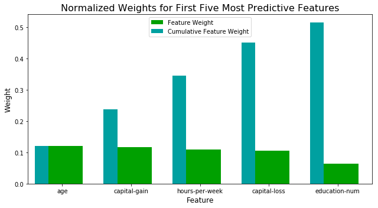

```python
# Extract the feature importances using .feature_importances_
importances = best_clf.feature_importances_

# Plot the top 5 features
vs.feature_plot(importances, X_train, y_train)
```

### Feature Selection

How does a model perform if we only use a subset of all the available features in the data? With fewer features required to train, the expectation is that training and prediction time is much lower — at the cost of performance metrics. From the visualization above, we see that the top five most important features contribute more than half of the importance of **all** features present in the data. This hints that we can attempt to *reduce the feature space* and simplify the information required for the model to learn. The code cell below will use the same optimized model we found earlier, and train it on the same training set *with only the top five important features*.

```python
# Reduce the feature space
X_train_reduced = X_train[X_train.columns.values[(np.argsort(importances)[::-1]
                                                  )[:5]]]
X_test_reduced = X_test[X_test.columns.values[(np.argsort(importances)[::-1]
                                               )[:5]]]

# Train on the "best" model found from grid search earlier
clf = (clone(best_clf)).fit(X_train_reduced, y_train)

# Make new predictions
reduced_predictions = clf.predict(X_test_reduced)

# Report scores from the final model using both versions of data
print("Final Model trained on full data\n------")
print("Accuracy on testing data: {:.4f}".format(
    accuracy_score(y_test, best_predictions)))
print("F-score on testing data: {:.4f}".format(
    fbeta_score(y_test, best_predictions, beta=0.5)))
print("\nFinal Model trained on reduced data\n------")
print("Accuracy on testing data: {:.4f}".format(
    accuracy_score(y_test, reduced_predictions)))
print("F-score on testing data: {:.4f}".format(
    fbeta_score(y_test, reduced_predictions, beta=0.5)))
```

```
Final Model trained on full data
------
Accuracy on testing data: 0.8719
F-score on testing data: 0.7547

Final Model trained on reduced data
------
Accuracy on testing data: 0.8425
F-score on testing data: 0.6993
```